# Cleaning, manipulating and analyzing of survey data from User and Device Agency for understanding human and computer interaction

## Process survey data

The survey data used in this analysis is a Dataset for Studying How Human Relates to their Smart Devices (https://www.preprints.org/manuscript/202102.0567/v1) collected by Heidi Toivonen and Francesco Lelli as part of their research for investigating the relationship people have with their smart devices. This data is used in Agency in Human-Smart Device Relationships: An Exploratory Study (https://www.preprints.org/manuscript/202009.0495/v2), written by Heidi Toivonen and Francesco Lelli in September 2020.

The Excel file was imported to Google Sheets and and split up into different worksheets. These worksheets were downloaded as csv files.

Code required for knitr to work and output figures.

```r
r = getOption("repos")
r["CRAN"] = "http://cran.us.r-project.org"
options(repos = r)
knitr::opts_chunk$set(fig.width=9)
```

## Import csv files of survey data

```r
setwd('~/Projects/coursera/Bellabeat Case Study/user_and_device_agency_survey/')
survey_data <- read.csv('survey_data.csv', header=TRUE)
survey_questions <- read.csv('survey_questions.csv', header=TRUE)
likert_scale <- read.csv('likert_scale.csv', header=TRUE)
device_category <- read.csv('device_category.csv', header=TRUE)
```

## Install packages

```r
install.packages('tidyverse')
```

```r
install.packages('ggplot2')
library(tidyverse)
library(ggplot2)
```

## View sample of the data

```r
tibble(survey_data)
```

```
## # A tibble: 809 × 53
##    Respondent Q_consent   Q17   Q19   Q20   Q21   Q22   Q32   Q29   Q30 Q2023
##         <int>     <int> <int> <int> <int> <int> <int> <int> <int> <int> <int>
##  1          1         1    NA    NA    NA    NA    NA    NA    NA    NA    NA
##  2          2         1     3     1     7     8     9     1     2     2   122
##  3          3         1     2     2     2     1     1     2     1     1   122
##  4          4         1     3     1     3     7     9     1     1     2   122
##  5          5         1     3     1     3     8     9     1     1     2   122
##  6          6         1     9     1     4     8     6     2     1     2   122
##  7          7         1     5     1     4     8     2     1     2     2   122
##  8          8         1     3     1     7     7     2     1     1     2   122
##  9          9         1     9     2     2     8     7     1     2     2   187
## 10         10         1     9     1     5     7     7     1     1     2    61
## # … with 799 more rows, and 42 more variables: Q2025 <int>, Q16 <int>,
## #   Q2 <chr>, Q3_1 <int>, Q3_2 <int>, Q3_3 <int>, Q3_4 <int>, Q3_5 <int>,
## #   Q3_6 <int>, Q3_7 <int>, Q3_8 <int>, Q4_1 <int>, Q4_2 <int>, Q4_3 <int>,
## #   Q4_4 <int>, Q4_5 <int>, Q4_6 <int>, Q4_7 <int>, Q4_8 <int>, Q5_1 <int>,
## #   Q5_2 <int>, Q5_3 <int>, Q5_4 <int>, Q6_1 <int>, Q6_2 <int>, Q6_3 <int>,
## #   Q7_1 <int>, Q7_2 <int>, Q7_3 <int>, Q8_1 <int>, Q8_2 <int>, Q8_3 <int>,
## #   Q9_1 <int>, Q9_2 <int>, Q9_3 <int>, Q10_1 <int>, Q10_2 <int>, …
```

## Filter survey data for women respondents

According to the survey questionnaire Survey_UserRelationshipWithTheirSmartDevice.pdf, **Question 19 Sex** has the following responses:

1 Male 2 Female 3 Other 4 Prefer Not to Say

Filter the survey data for women.

```r
survey_data_women <- survey_data %>%
  filter(Q19 == 2)
```

## Smart Device Categories

From the survey, the most common device that women have are Smart Watches like Polar or Fitbit. A few women have other personal health devices like a blood pressure monitor.

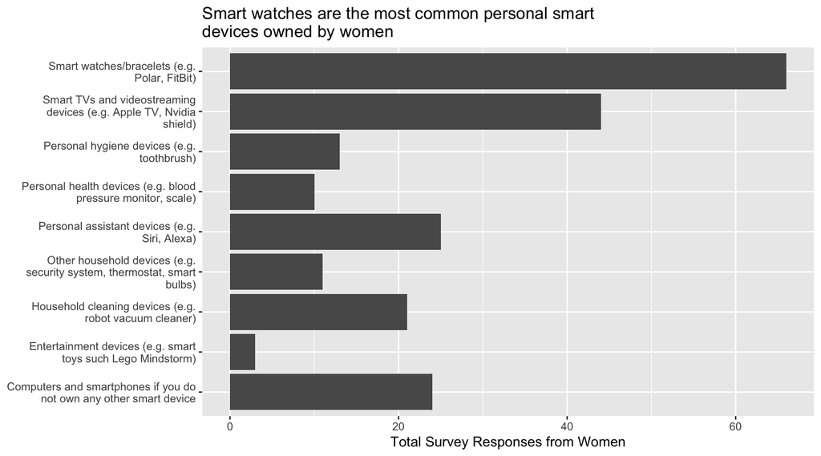

## Filter survey data for women respondents who have smart watches

The survey has two device categories of interest that might be of interest - Smart Watches and Personal Health Devices. The Personal Health Device category (e.g.blood pressure monitor or scale) is not included in this analysis because it does not directly correspond to any of the Bellabeat products.

```r
women_personal_devices <- survey_data_women %>%
  filter(Q16 == 1)
```

## Clean and reorganize survey data to analyze qualities that characterize human interaction with (technological) objects

According to the authors of the study, the data collected in the survey can be used to analyse following attributes: - usability, the pragmatic attributes, or functionality of the device - cost-effectiveness or price utility, the perceived efficient use of money - self-extension or identification with the device - the social aspect of devices, such as social status or social self-image expression and the device’s capacity to enhance the user’s social relationships - the emotional aspects of using the device, such as joy or aesthetic pleasure - anthropomorphism, attributing human-like qualities to the device

```r
install.packages('stringr')
library(stringr)
```

### Analysing cost-effectiveness or price utility, the perceived efficient use of money

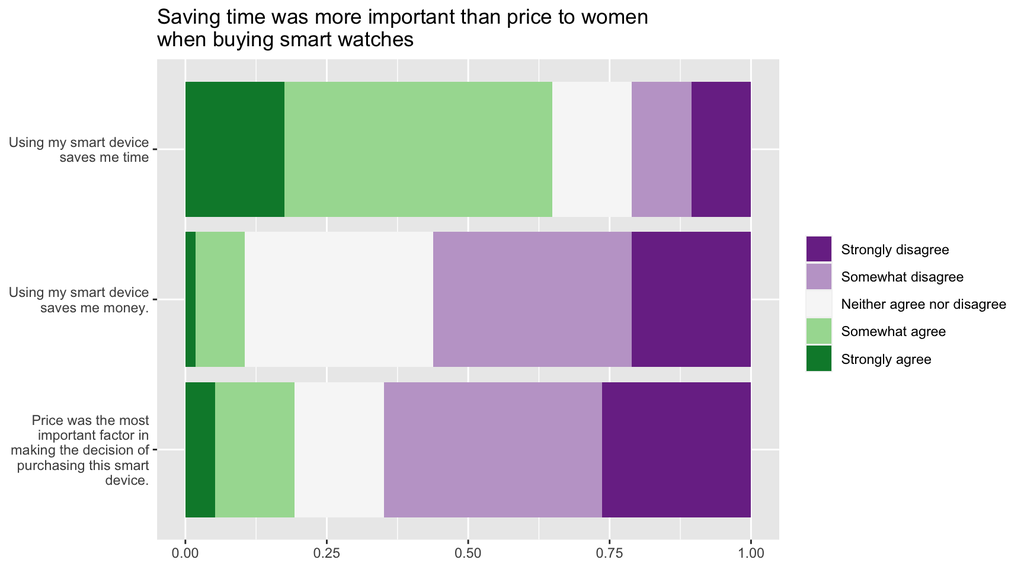

### Analysing the social aspect of devices, such as social status or social self-image expression and the device’s capacity to enhance the user’s social relationships

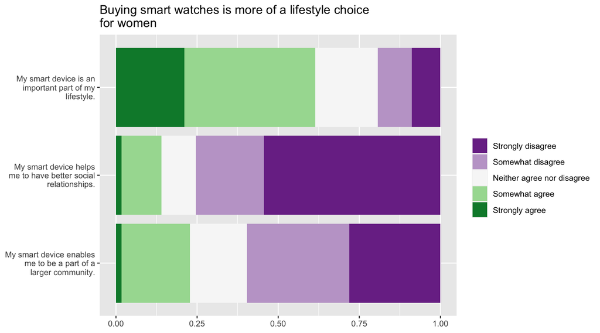

## Analysing usability, the pragmatic attributes, or functionality of the device

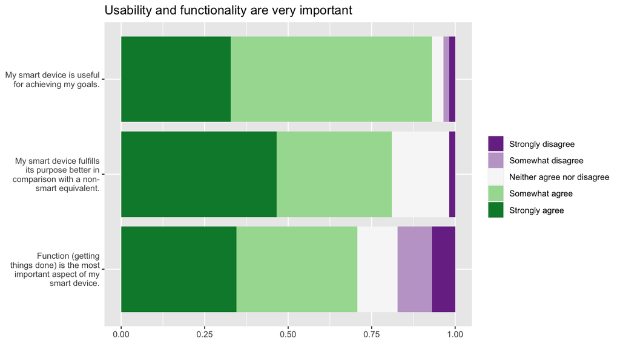